# Tenth Week: Principal Component Analysis and Factor Analysis

PCA Stock, image, …

Mohammad amin Roohi

2018-05-20 02:47:45

> با استفاده از داده های OHLCV شرکت های تشکیل دهنده شاخص s&p500 و همچنین داده مربوط به شاخص های اقتصادی به سوالات زیر پاسخ دهید.

```r
library(readr)
library(ggplot2)
library(dplyr)
library(stringi)
library(stringr)
library(qcc)
library(EBImage)
```

۱. چه شرکتی رکورددار کسب بیشترین سود در بازه یکساله، دو ساله و پنج ساله می باشد؟ این سوال را برای بخش های مختلف مورد مطالعه قرار دهید و رکورددار را معرفی کنید. (برای این کار به ستون sector داده constituents مراجعه کنید.) برای هر دو قسمت نمودار سود ده شرکت و یا بخش برتر را رسم نمایید.

```r
years = c("2000" , "2001" , "2002" , "2003" , "2004" , "2005" , "2006" , "2007" , "2008" ,
          "2009" , "2010" , "2011" , "2012" , "2013" , "2014" , "2015" , "2016")



gain = NULL

companies = list.files("D:/University/Semester8/Data analysis/week9/data/stock_dfs")

for(i in companies){

  k = NULL

  add = paste("D:/University/Semester8/Data analysis/week9/data/stock_dfs/" , i , sep = "")

  x = read.csv(add)

  for(j in years){


    x %>% filter(str_detect(x$Date , j)) ->x1

    k = c(k , sum(x1$Close) - sum(x1$Open))


  }

  gain = c(gain , max(k))

}

m = max(gain)

m = match(m , gain)

print(paste("Most gain in one year is for" , companies[m] %>% str_remove(".csv") , "company"))
```

```
## [1] "Most gain in one year is for BRK-B company"
```

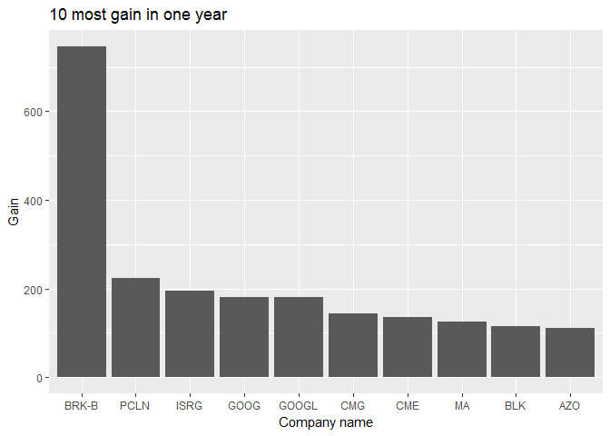

```r
a = sort(gain , decreasing = T)

a = a[1:10]

n = match(a , gain)

companies[n] %>% str_remove(".csv") -> n

d = data.frame(a , n)

colnames(d) = c("Gain" , "Company")

ggplot(d , aes(x = reorder(Company , -Gain) , y = Gain)) + geom_col() + ggtitle("10 most gain in one year") + xlab("Company name")
```

```r
###



years = c("2000" , "2001" , "2002" , "2003" , "2004" , "2005" , "2006" , "2007" , "2008" ,
          "2009" , "2010" , "2011" , "2012" , "2013" , "2014" , "2015" , "2016")



gain = NULL

companies = list.files("D:/University/Semester8/Data analysis/week9/data/stock_dfs")

for(i in companies){

  k = NULL

  add = paste("D:/University/Semester8/Data analysis/week9/data/stock_dfs/" , i , sep = "")

  x = read.csv(add)

  for(j in 1:16){


    x %>% filter(str_detect(x$Date , years[j])) ->x1

    x %>% filter(str_detect(x$Date , years[j+1])) ->x2

    x1 = rbind(x1 , x2)

    k = c(k , sum(x1$Close) - sum(x1$Open))


  }

  gain = c(gain , max(k))

}

m = max(gain)

m = match(m , gain)

print(paste("Most gain in two years is for" , companies[m] %>% str_remove(".csv") , "company"))
```

```
## [1] "Most gain in two years is for BRK-B company"
```

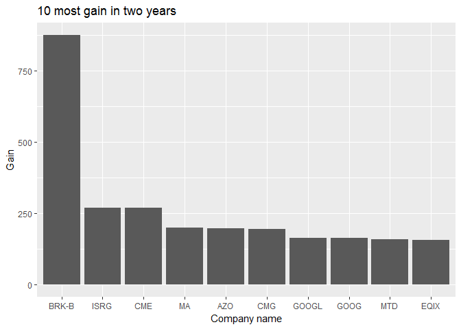

```r
a = sort(gain , decreasing = T)

a = a[1:10]

n = match(a , gain)

companies[n] %>% str_remove(".csv") -> n

d = data.frame(a , n)

colnames(d) = c("Gain" , "Company")

ggplot(d , aes(x = reorder(Company , -Gain) , y = Gain)) + geom_col() + ggtitle("10 most gain in two years") + xlab("Company name")
```

```r
###



years = c("2000" , "2001" , "2002" , "2003" , "2004" , "2005" , "2006" , "2007" , "2008" ,
          "2009" , "2010" , "2011" , "2012" , "2013" , "2014" , "2015" , "2016")



gain = NULL

companies = list.files("D:/University/Semester8/Data analysis/week9/data/stock_dfs")

for(i in companies){

  k = NULL

  add = paste("D:/University/Semester8/Data analysis/week9/data/stock_dfs/" , i , sep = "")

  x = read.csv(add)

  for(j in 1:13){


    x %>% filter(str_detect(x$Date , years[j])) ->x1

    x %>% filter(str_detect(x$Date , years[j+1])) ->x2

    x %>% filter(str_detect(x$Date , years[j+2])) ->x3

    x %>% filter(str_detect(x$Date , years[j+3])) ->x4

    x %>% filter(str_detect(x$Date , years[j+4])) ->x5

    x1 = rbind(x1, x2, x3, x4, x5)

    k = c(k , sum(x1$Close) - sum(x1$Open))


  }

  gain = c(gain , max(k))

}

m = max(gain)

m = match(m , gain)

print(paste("Most gain in five years is for" , companies[m] %>% str_remove(".csv") , "company"))
```

```
## [1] "Most gain in five years is for BRK-B company"
```

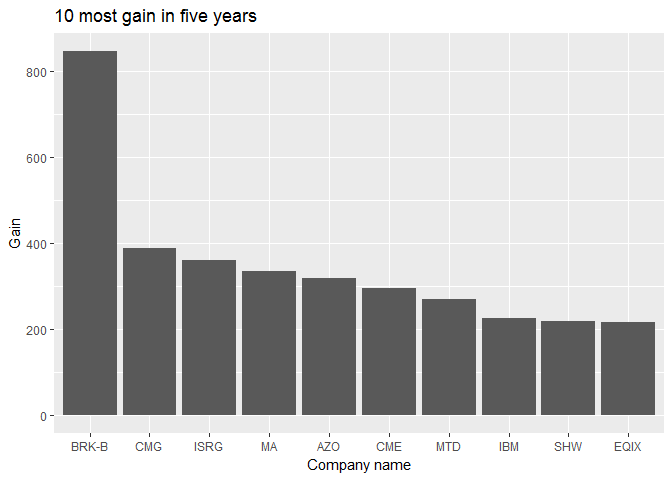

```r
a = sort(gain , decreasing = T)

a = a[1:10]

n = match(a , gain)

companies[n] %>% str_remove(".csv") -> n

d = data.frame(a , n)

colnames(d) = c("Gain" , "Company")

ggplot(d , aes(x = reorder(Company , -Gain) , y = Gain)) + geom_col() + ggtitle("10 most gain in five years") + xlab("Company name")
```

```r
###
x = read.csv("D:/University/Semester8/Data analysis/week9/data/constituents.csv")

years = c("2000" , "2001" , "2002" , "2003" , "2004" , "2005" , "2006" , "2007" , "2008" ,
          "2009" , "2010" , "2011" , "2012" , "2013" , "2014" , "2015" , "2016")

y = read.csv("D:/University/Semester8/Data analysis/week9/data/indexes.csv")
companies = list.files("D:/University/Semester8/Data analysis/week9/data/stock_dfs") %>% str_remove(".csv")

x1 = read.csv(paste("D:/University/Semester8/Data analysis/week9/data/stock_dfs/" , companies[1] , ".csv" , sep =""))

sectors = c("Industrials", "Health Care", "Information Technology" , "Consumer Discretionary" , "Utilities", "Financials", "Materials", "Real Estate", "Consumer Staples", "Energy", "Telecommunication Services")

gain = NULL

for(i in sectors){

  k = 0

  d = x %>% filter(Sector == i)

  s = d$Symbol

  fil = NULL

  for(j in s){

    if(sum(j == companies)){

      fil = c(fil , TRUE)

    }

    if(sum(j == companies) == 0){

      fil = c(fil , FALSE)

    }

  }


  d = d %>% filter(fil)

  aaa = NULL


  for(r in d$Symbol){



    add = paste("D:/University/Semester8/Data analysis/week9/data/stock_dfs/" , r , ".csv" , sep ="")

    p = read.csv(add)

    aaa = rbind(aaa , p)


  }

  gg = NULL

  for(j in years){


    aaa %>% filter(str_detect(aaa$Date , j)) ->aaa1

    gg = c(gg , sum(aaa1$Close) - sum(aaa1$Open))


  }

  gain = c(gain , max(gg))



}



match(max(gain) , gain) -> m

print(paste("Most gain in one year in sectors is for" , sectors[m]))
```

```
## [1] "Most gain in one year in sectors is for Information Technology"
```

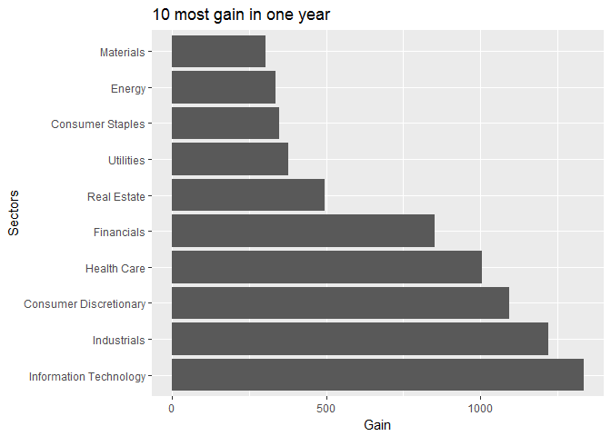

```r
a = sort(gain , decreasing = T)

a = a[1:10]

n = match(a , gain)

sectors[n] %>% str_remove(".csv") -> n

d = data.frame(a , n)

colnames(d) = c("Gain" , "Sectors")

ggplot(d , aes(x = reorder(Sectors , -Gain) , y = Gain)) + geom_col() + ggtitle("10 most gain in one year") + xlab("Sectors") + coord_flip()
```

```r
###



x = read.csv("D:/University/Semester8/Data analysis/week9/data/constituents.csv")

years = c("2000" , "2001" , "2002" , "2003" , "2004" , "2005" , "2006" , "2007" , "2008" ,
          "2009" , "2010" , "2011" , "2012" , "2013" , "2014" , "2015" , "2016")

y = read.csv("D:/University/Semester8/Data analysis/week9/data/indexes.csv")
companies = list.files("D:/University/Semester8/Data analysis/week9/data/stock_dfs") %>% str_remove(".csv")

x1 = read.csv(paste("D:/University/Semester8/Data analysis/week9/data/stock_dfs/" , companies[1] , ".csv" , sep =""))

sectors = c("Industrials", "Health Care", "Information Technology" , "Consumer Discretionary" , "Utilities", "Financials", "Materials", "Real Estate", "Consumer Staples", "Energy", "Telecommunication Services")

gain = NULL

for(i in sectors){

  k = 0

  d = x %>% filter(Sector == i)

  s = d$Symbol

  fil = NULL

  for(j in s){

    if(sum(j == companies)){

      fil = c(fil , TRUE)

    }

    if(sum(j == companies) == 0){

      fil = c(fil , FALSE)

    }

  }


  d = d %>% filter(fil)

  aaa = NULL

  for(r in d$Symbol){



    add = paste("D:/University/Semester8/Data analysis/week9/data/stock_dfs/" , r , ".csv" , sep ="")

    p = read.csv(add)

    aaa = rbind(aaa , p)


  }

  gg = NULL

  for(j in 1:16){


    aaa %>% filter(str_detect(aaa$Date , years[j])) ->aaa1

    aaa %>% filter(str_detect(aaa$Date , years[j+1])) ->aaa2

    aaa1 = rbind(aaa1 , aaa2)

    gg = c(gg , sum(aaa1$Close) - sum(aaa1$Open))


  }

  gain = c(gain , max(gg))



}



match(max(gain) , gain) -> m

print(paste("Most gain in two year in sectors is for" , sectors[m]))
```

```
## [1] "Most gain in two year in sectors is for Consumer Discretionary"
```

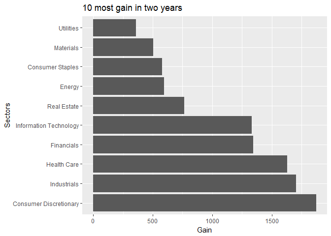

```r
a = sort(gain , decreasing = T)

a = a[1:10]

n = match(a , gain)

sectors[n] %>% str_remove(".csv") -> n

d = data.frame(a , n)

colnames(d) = c("Gain" , "Sectors")

ggplot(d , aes(x = reorder(Sectors , -Gain) , y = Gain)) + geom_col() + ggtitle("10 most gain in two years") + xlab("Sectors") + coord_flip()
```

```r
###

x = read.csv("D:/University/Semester8/Data analysis/week9/data/constituents.csv")

years = c("2000" , "2001" , "2002" , "2003" , "2004" , "2005" , "2006" , "2007" , "2008" ,
          "2009" , "2010" , "2011" , "2012" , "2013" , "2014" , "2015" , "2016")

y = read.csv("D:/University/Semester8/Data analysis/week9/data/indexes.csv")
companies = list.files("D:/University/Semester8/Data analysis/week9/data/stock_dfs") %>% str_remove(".csv")

x1 = read.csv(paste("D:/University/Semester8/Data analysis/week9/data/stock_dfs/" , companies[1] , ".csv" , sep =""))

sectors = c("Industrials", "Health Care", "Information Technology" , "Consumer Discretionary" , "Utilities", "Financials", "Materials", "Real Estate", "Consumer Staples", "Energy", "Telecommunication Services")

gain = NULL

for(i in sectors){

  k = 0

  d = x %>% filter(Sector == i)

  s = d$Symbol

  fil = NULL

  for(j in s){

    if(sum(j == companies)){

      fil = c(fil , TRUE)

    }

    if(sum(j == companies) == 0){

      fil = c(fil , FALSE)

    }

  }


  d = d %>% filter(fil)

  aaa = NULL

  for(r in d$Symbol){



    add = paste("D:/University/Semester8/Data analysis/week9/data/stock_dfs/" , r , ".csv" , sep ="")

    p = read.csv(add)

    aaa = rbind(aaa , p)


  }

  gg = NULL

  for(j in 1:13){


    aaa %>% filter(str_detect(aaa$Date , years[j])) ->aaa1

    aaa %>% filter(str_detect(aaa$Date , years[j+1])) ->aaa2

    aaa %>% filter(str_detect(aaa$Date , years[j+2])) ->aaa3

    aaa %>% filter(str_detect(aaa$Date , years[j+3])) ->aaa4

    aaa %>% filter(str_detect(aaa$Date , years[j+4])) ->aaa5

    aaa1 = rbind(aaa1 , aaa2 , aaa3 , aaa4 , aaa5)

    gg = c(gg , sum(aaa1$Close) - sum(aaa1$Open))


  }

  gain = c(gain , max(gg))



}



match(max(gain) , gain) -> m

print(paste("Most gain in five year in sectors is for" , sectors[m]))
```

```
## [1] "Most gain in five year in sectors is for Consumer Discretionary"
```

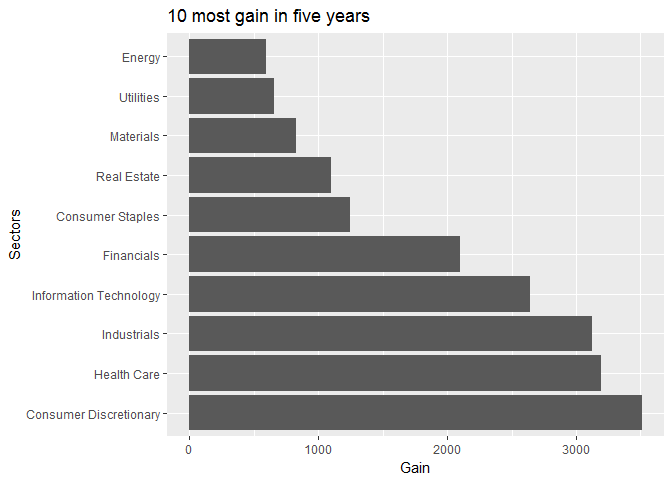

```r
a = sort(gain , decreasing = T)

a = a[1:10]

n = match(a , gain)

sectors[n] %>% str_remove(".csv") -> n

d = data.frame(a , n)

colnames(d) = c("Gain" , "Sectors")

ggplot(d , aes(x = reorder(Sectors , -Gain) , y = Gain)) + geom_col() + ggtitle("10 most gain in five years") + xlab("Sectors") + coord_flip()
```

۲. یک اعتقاد خرافی می گوید خرید سهام در روز سیزدهم ماه زیان آور است. این گزاره را مورد ارزیابی قرار دهید.

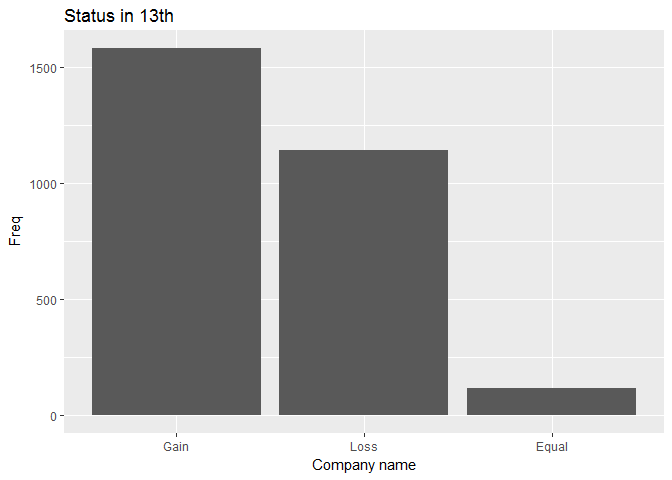

```r
gain = NULL

other_gain = NULL

years = c("2000" , "2001" , "2002" , "2003" , "2004" , "2005" , "2006" , "2007" , "2008" ,
          "2009" , "2010" , "2011" , "2012" , "2014" , "2015" , "2016")

companies = list.files("D:/University/Semester8/Data analysis/week9/data/stock_dfs")

for(i in companies){

  add = paste("D:/University/Semester8/Data analysis/week9/data/stock_dfs/" , i , sep = "")

  x = read.csv(add)

  x %>% filter(str_detect(x$Date , years)) ->x1

  x1 %>% filter(str_detect(x1$Date , "13")) ->x1

  x %>% anti_join(x1) -> x2

  x1 %>% mutate(g = x1$Close - x1$Open) -> x1

  x2 %>% mutate(g = x2$Close - x2$Open) -> x2

  gain = c(gain , x1$g)

  other_gain = c(other_gain , x2$g)
}

d = table(sign(gain))

df = data.frame(d , c("Loss" , "Equal" , "Gain"))

colnames(df) = c("type" , "Freq" , "Value")


ggplot(df , aes(x = reorder(Value , -Freq) , y = Freq)) + geom_col() + ggtitle("Status in 13th") + xlab("Company name")
```

```r
###

g1 = sign(gain)
g2 = sign(other_gain)
g2 = sample(g2 , length(g1))

t.test(g1 , g2)
```

```
##
##  Welch Two Sample t-test
##
## data:  g1 and g2
## t = 5.0732, df = 5684.1, p-value = 4.035e-07
## alternative hypothesis: true difference in means is not equal to 0
## 95 percent confidence interval:
##  0.08087671 0.18274367
## sample estimates:
##  mean of x  mean of y
## 0.15430580 0.02249561
```

۳. رکورد بیشترین گردش مالی در تاریخ بورس برای چه روزی بوده است و چرا!!!

```r
companies = list.files("D:/University/Semester8/Data analysis/week9/data/stock_dfs")


volume = rep(0 , 4277)

for(j in companies){

    add = paste("D:/University/Semester8/Data analysis/week9/data/stock_dfs/" , j , sep ="")

    x = read.csv(add)

    volume = volume + x$Volume

}

add = paste("D:/University/Semester8/Data analysis/week9/data/stock_dfs/" , companies[1] , sep ="")

x = read.csv(add)

m = match(max(volume) , volume)

d = x$Date[m]

print(paste("Max Total Volume is in",d))
```

```
## [1] "Max Total Volume is in 2008-10-10"
```

۴. شاخص AAPL که نماد شرکت اپل است را در نظر بگیرید. با استفاده از رگرسیون خطی یک پیش کننده قیمت شروع (open price) بر اساس k روز قبل بسازید. بهترین انتخاب برای k چه مقداری است؟ دقت پیش بینی شما چقدر است؟

```r
x = read.csv("D:/University/Semester8/Data analysis/week9/data/stock_dfs/AAPL.csv")

o = x$Open

r_squared = NULL

for(i in 1:10){

  q = data.frame(o[(i + 1):4277] , o[1:(4277 - i)])

  colnames(q) = c("Today Price" , "Price in i days before")

  fit = lm(q$`Today Price` ~ q$`Price in i days before`)

  r_squared = c(r_squared , summary(fit)$r.squared)

}

m = match(min(r_squared) , r_squared)

print(paste("The best value for k is" , m))
```

```
## [1] "The best value for k is 10"
```

```r
q = data.frame(o[(m + 1):4277] , o[1:(4277 - m)])

colnames(q) = c("Today Price" , paste("Price in" , m , "days before"))

fit = lm(q$`Today Price` ~ q$`Price in 10 days before`)

print(paste("The R_squared is",summary(fit)$r.squared))
```

```
## [1] "The R_squared is 0.970730505200704"
```

```r
q %>% mutate(pred = predict(fit , q)) ->q
```

۵. بر روی داده های قیمت شروع شرکت ها الگوریتم pca را اعمال کنید. نمودار تجمعی درصد واریانس بیان شده در مولفه ها را رسم کنید. سه مولفه اول چند درصد از واریانس را تبیین می کند؟

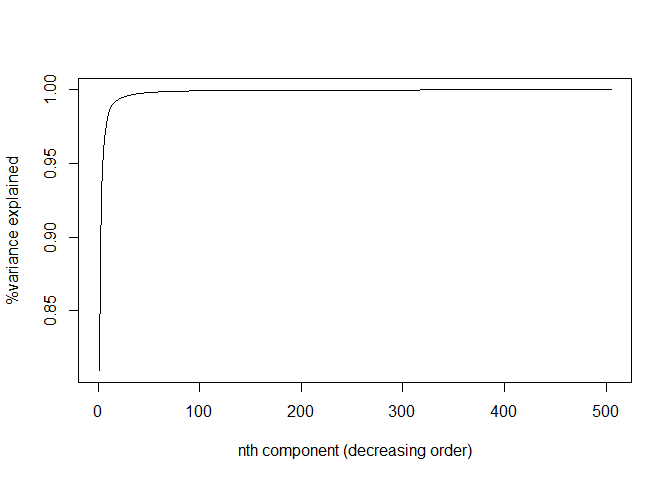

```r
companies = list.files("D:/University/Semester8/Data analysis/week9/data/stock_dfs")

add = paste("D:/University/Semester8/Data analysis/week9/data/stock_dfs/" , companies[1] , sep ="")

x = read.csv(add)

d = data.frame(x$Open)

for(i in 2:505){

  add = paste("D:/University/Semester8/Data analysis/week9/data/stock_dfs/" , companies[i] , sep ="")

  x = read.csv(add)

  a = c(x$Open , rep(0 , 4277 - length(x$Open)))

  d = data.frame(d , a)

}

pca = prcomp(d)
plot(summary(pca)$importance[3,], type="l",
     ylab="%variance explained", xlab="nth component (decreasing order)")
```

```r
print((pca$sdev[1]^2 + pca$sdev[2]^2 + pca$sdev[3]^2)/sum(pca$sdev^2))
```

```
## [1] 0.9300858
```

۶. برای هر نماد اطلاعات بخش مربوطه را از داده constituents استخراج نمایید. برای هر بخش میانگین روزانه قیمت شروع شرکت های آن را محاسبه کنید. سپس با استفاده از میانگین به دست آمده داده ایی با چند ستون که هر ستون یک بخش و هر سطر یک روز هست بسازید. داده مربوط را با داده شاخص های اقتصادی ادغام کنید. بر روی این داده pca بزنید و نمودار biplot آن را تفسیر کنید.

مشاهده می شود تاثیر مولفه اول بر قیمت زیاد است.

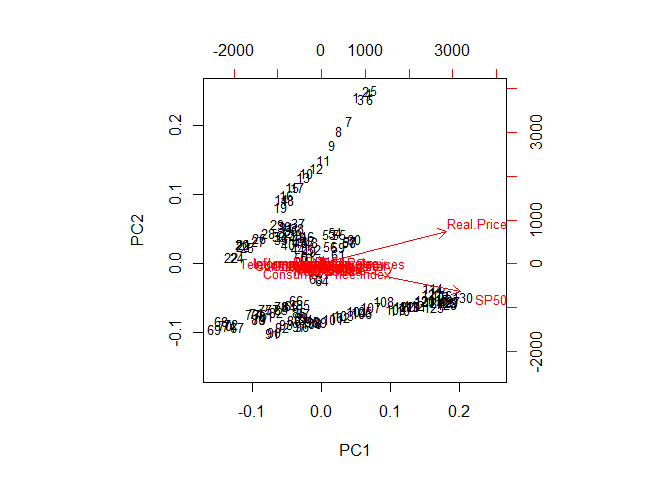

```r
x = read.csv("D:/University/Semester8/Data analysis/week9/data/constituents.csv")


y = read.csv("D:/University/Semester8/Data analysis/week9/data/indexes.csv")

companies = list.files("D:/University/Semester8/Data analysis/week9/data/stock_dfs") %>%
  str_remove(".csv")

sym = x$Symbol

x1 = read.csv(paste("D:/University/Semester8/Data analysis/week9/data/stock_dfs/" , companies[1] , ".CSV" , sep =""))

sectors = c("Industrials", "Health Care", "Information Technology" , "Consumer Discretionary" , "Utilities", "Financials", "Materials", "Real Estate", "Consumer Staples", "Energy", "Telecommunication Services")

ave = x1$Date

for(i in sectors){

  k = 0

  d = x %>% filter(Sector == i)

  s = d$Symbol

  fil = NULL

  for(j in s){

    if(sum(j == companies)){

      fil = c(fil , TRUE)

    }

    if(sum(j == companies) == 0){

      fil = c(fil , FALSE)

    }

  }


  d = d %>% filter(fil)

  aaa = rep(0 , 4277)

  for(r in d$Symbol){

    add = paste("D:/University/Semester8/Data analysis/week9/data/stock_dfs/" , r , ".csv" , sep ="")

    p = read.csv(add)

    p = c(p$Open , rep(0 , 4277 - length(p$Open)))

    aaa = aaa + p


  }

  aaa = aaa / length(d$Symbol)

  ave = data.frame(ave , aaa)


}

n = c("Date" , sectors)

colnames(ave) = n

merge(x = ave, y = y, by = "Date", all = FALSE) -> w

w = w[, 2:21]

pca = prcomp(w)

biplot(pca,cex=0.8)
```

***

۷. روی همه اطلاعات (OHLCV) سهام اپل الگوریتم PCA را اعمال کنید. سپس از مولفه اول برای پیش بینی قیمت شروع سهام در روز آینده استفاده کنید. به سوالات سوال ۴ پاسخ دهید. آیا استفاده از مولفه اول نتیجه بهتری نسبت به داده open price برای پیش بینی قیمت دارد؟

```r
x = read.csv("D:/University/Semester8/Data analysis/week9/data/stock_dfs/AAPL.csv")

pca = prcomp(x[,2:7] , scale. = T , center = T , retx = T)

fit = lm(x$Open ~ pca$x[,1])

pred = predict(fit , x)

err = (sum(((x$Open - pred)^2)) / length(x$Open))^0.5

print(paste("The error is" ,err))
```

```
## [1] "The error is 22.3019282747914"
```

```r
print(paste("The R_squared is",summary(fit)$r.squared))
```

```
## [1] "The R_squared is 0.983493060220716"
```

۸. نمودار سود نسبی شاخص s&p500 را رسم کنید. آیا توزیع سود نرمال است؟(از داده indexes استفاده کنید.) با استفاده از ده مولفه اول سوال پنج آیا می توانید سود و ضرر شاخص s&p500 را برای روز آينده پیش بینی کنید؟ از یک مدل رگرسیون لاجستیک استفاده کنید. درصد خطای پیش بینی را به دست آورید.

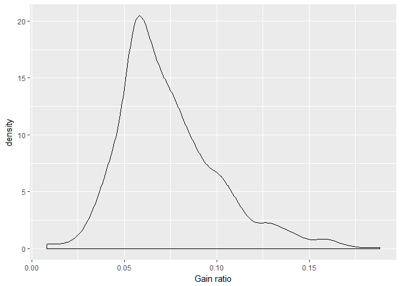

```r
indexes = read.csv("D:/University/Semester8/Data analysis/week9/data/indexes.csv")

indexes %>% mutate(aaa = Real.Earnings / Real.Price) -> indexes

p = ggplot(indexes , aes(indexes$aaa)) + geom_density() + xlab("Gain ratio")


print(p)
```

***

۹. عکسی که در ابتدای متن آمده را در نظر بگیرید. با استفاده از pca عکس را فشرده کنید. سپس نمودار حجم عکس فشرده بر حسب تعداد مولفه اصلی را رسم کنید. بهترین انتخاب برای انتخاب تعداد مولفه ها در جهت فشرده سازی چه عددی است؟

```r
pic = flip(readImage("D:/University/Semester8/Data analysis/week9/hw_09/images/stock.jpg"))

red.weigth   = .2989; green.weigth = .587; blue.weigth  = 0.114

img = red.weigth * imageData(pic)[,,1] +
+     green.weigth * imageData(pic)[,,2] + blue.weigth  * imageData(pic)[,,3]

pca.img = prcomp(img, scale=TRUE)

a = pca.img$sdev
b = length(a)
for(i in 1:b){
  if((sum(a[1:i]^2)/sum(a^2))>0.99){print(paste("Number of components for getting 0.99  of variance explained is",i))
break()}}
```

```
## [1] "Number of components for getting 0.99  of variance explained is 109"
```

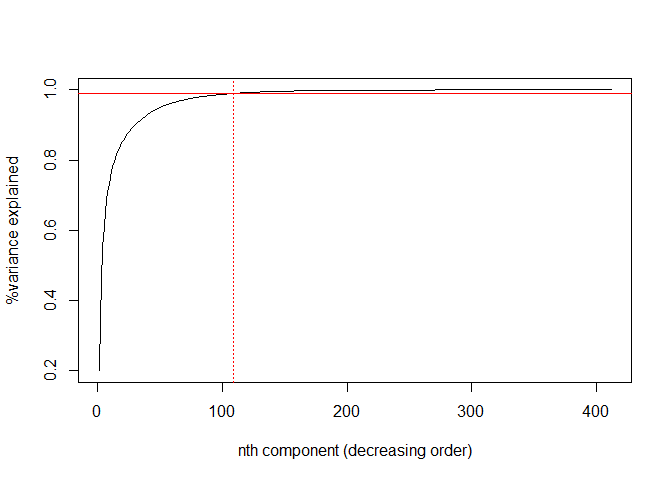

```r
plot(summary(pca.img)$importance[3,], type="l", ylab="%variance explained", xlab="nth component (decreasing order)")

abline(h=0.99,col="red");abline(v = 109,col="red",lty=3)
```

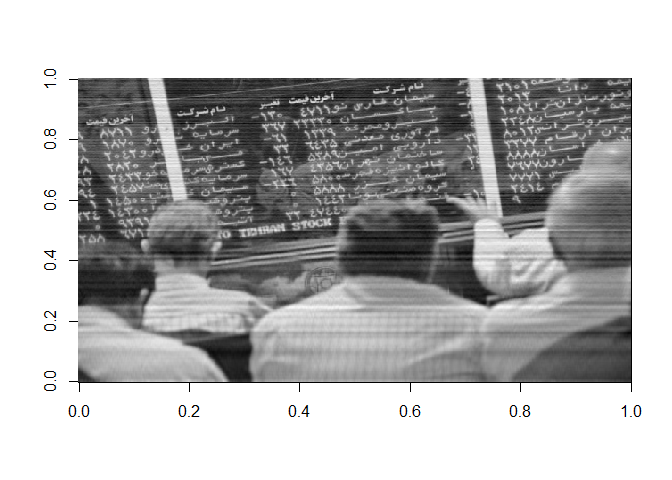

```r
chosen.components = 1:109

feature.vector = pca.img$rotation[,chosen.components]

compact.data = t(feature.vector) %*% t(img)

approx.img = t(feature.vector %*% compact.data)

image(approx.img, col = grey(seq(0, 1, length = 256)))
```

***

۱۰. پنج ایده جالبی که روی داده های مالی بالا می توانستیم پیاده کنیم را بیان کنید. (ایده کافی است نیازی به محاسبه بر روی داده نیست.)

1.آیا توزیع قیمت سهام شرکت های مختف بر حسب زمان یکسان است؟(در تاریخ هایی با هم زیاد می شوند و در تاریخ هایی با هم کم می شوند؟)

2.آیا قیمت شروع روی حجم مبادلاتی تاثیر می گذارد؟

3.اگر اختلاف بیشترین و کم ترین قیمت را نوسانی شدن بنامیم، آنگاه نوسانی شدن چه تاثیری بر حجم مبادلاتی دارد؟

4.سود زیاد روی هر سهم بهتر است یا سود کمتر رو سهم اما حجم مبادلاتی بالا؟

5.اگر بخواهیم در بورس سرمایه گذاری کنیم، بهتر است در بخش های مختلف و شرکت های مختلف سرمایه گذاری کنیم یا یک شرکت با سود بالا انتخاب کرده و سهام آن را بخریم؟